# Winter COVID Data Project

Gilberto Padilla Mercado

## Introduction

First we need to load the necessary packages and the data. I will be using a select number of packages from the tidyverse and svglite.

```r
library(knitr)
library(lubridate)
library(readr)
library(magrittr)
library(dplyr)
library(stringr)
library(ggplot2)
library(svglite)
```

The CDC data on COVID-19 can be found [here](https://data.cdc.gov/Case-Surveillance/United-States-COVID-19-Cases-and-Deaths-by-State-o/9mfq-cb36) saved here as `covid`, and the `timeline` is part of the [online CDC museum](https://www.cdc.gov/museum/timeline/covid19.html).

As this data loads in, I also make sure the timeline is processed into Date format.

| Day | Event |
| --- | --- |
| 2020-01-20 | First reported US case. |
| 2020-03-15 | US Begins to shut down. |
| 2020-03-17 | Moderna Trial Begins. |
| 2020-03-26 | Senate Passes CARES Act. |
| 2020-03-28 | US FDA issues EUA to allow anti-malarial drugs to treat COVID-19. |
| 2020-04-13 | White House announces U.S. will cease funding the WHO. |

I also parse through the longitudinal data into date format. To label the important dates in the timeline, I also convert the POSIXct into a numeric.

```r
covid_parsed <- covid %>% mutate(submission_date = strptime(submission_date,
                                                     format = "%m/%d/%Y"),
                          created_at = strptime(created_at,
                                                format = "%m/%d/%Y %H:%M:%S %p"))

timeline_parsed <- as.numeric(ymd(timeline$Day))
```

## Summarizing and plotting the data

The data are ready to be summarized. There are many potential data-points to visualize, but I was particularly interested in new and total counts of cases and deaths, to really understand the tremendous impact of the pandemic.

```r
covid_parsed <- covid_parsed %>%
    group_by(state, week = floor_date(submission_date, unit = "week")) %>%
    summarize(med_cases_new = median(new_case),
              med_deaths_new = median(new_death),
              med_cases_tot = median(tot_cases),
              med_deaths_tot = median(tot_death)) %>% ungroup()
```

I’ve made a ggplot2 function which will make it easier to plot each plot. I don’t include any geoms or aesthetics that we might want to change for each plot.

```r
timeplot <- ggplot(data = covid_parsed, aes(x = as.Date(week),
                          group = as.factor(state),
                          fill = as.factor(state))) +
  scale_fill_viridis_d(option = "magma") +
  xlab("") + ylab("") +
  theme_minimal() +
  theme(
    axis.text.x = element_text(hjust = 1, angle = 45),
    axis.line = element_line(color = "black", size = 1, lineend = "square"),
    panel.grid = element_blank(),
    panel.grid.major.y = element_line(color = "lightgray", size = 1),
    legend.position = "none"
    )
```

Here is the first plot I generate, looking at the median new cases for every week.

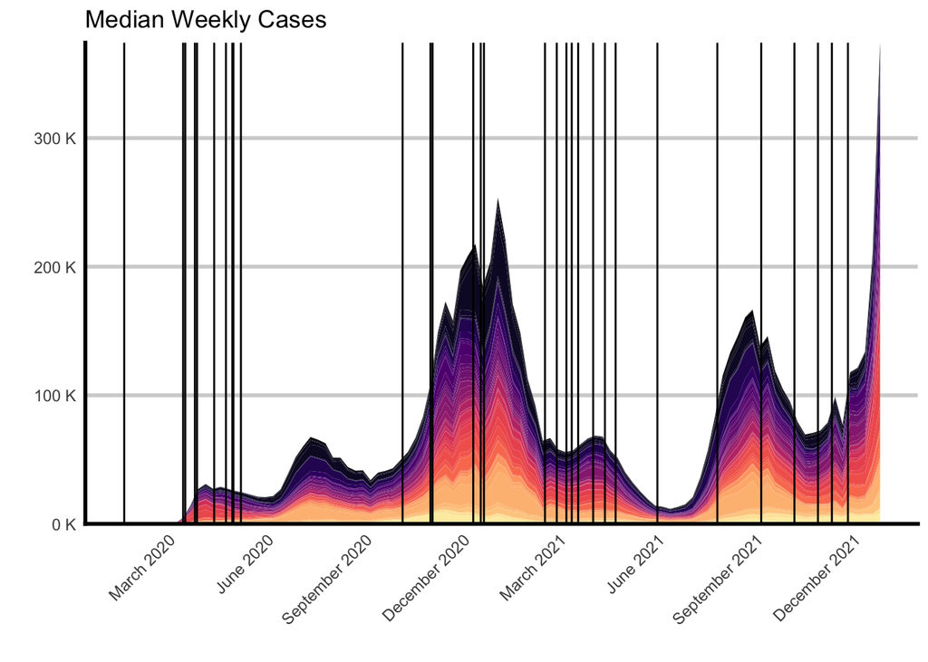

```r
timeplot + labs(title = "Median Weekly Cases") +
  geom_area(aes(y = med_cases_new)) +
  scale_x_date(date_breaks = "3 month", date_labels = str_to_upper("%b %Y")) +
  scale_y_continuous(labels = scales::unit_format(unit = "K", scale = 1e-3),
                       expand = c(0, NA)) +
  geom_vline(xintercept = timeline_parsed, col = "black", lwd = 0.5)
```

```r
ggsave("MedianTotalCases_Tutorial.svg", device = "svg", height = 5, width = 8)
```

We can save this for later as an scalable vector graphic, or `svg` file, before importing it into Illustrator to work on it some more.

This second plot does not include the vertical lines looking at events.

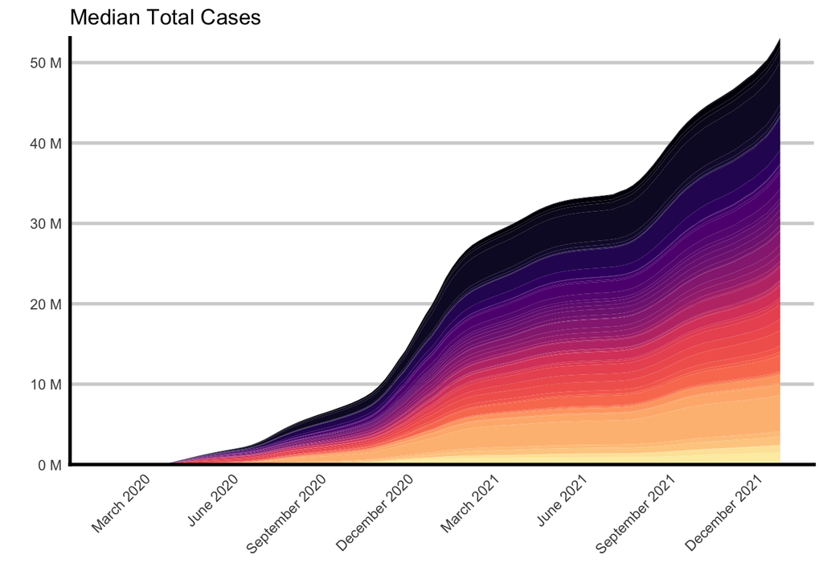

```r
timeplot + labs(title = "Median Total Cases") +
  geom_area(aes(y = med_cases_tot)) +
  scale_x_date(date_breaks = "3 month", date_labels = str_to_upper("%b %Y")) +
  scale_y_continuous(labels = scales::unit_format(unit = "M", scale = 1e-6),
                       expand = c(0, NA))
```

Instead of plotting the weekly cases, this shows the cumulative number of total cases over time. This is actually an imperfect measure due to counting any person that was or is COVID-19 positive, which can happen multiple times. To take a more accurate look at the tragedy that COVID-19 precipitated, we can take a look at cumulative deaths over time, since there is a far lower chance of any double counting.

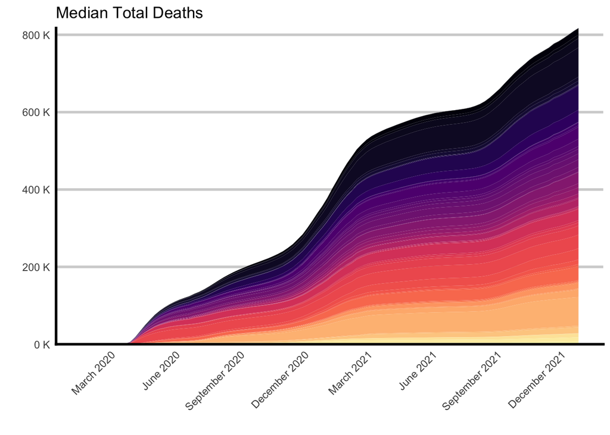

```r
timeplot + labs(title = "Median Total Deaths") +
  geom_area(aes(y = med_deaths_tot)) +
  scale_x_date(date_breaks = "3 month", date_labels = str_to_upper("%b %Y")) +
  scale_y_continuous(labels = scales::unit_format(unit = "K", scale = 1e-3),
                       expand = c(0, NA))
```

Finally after annotating our first plot in a vector graphics program (I used Illustrator) we are able to get a fully annotated plot.

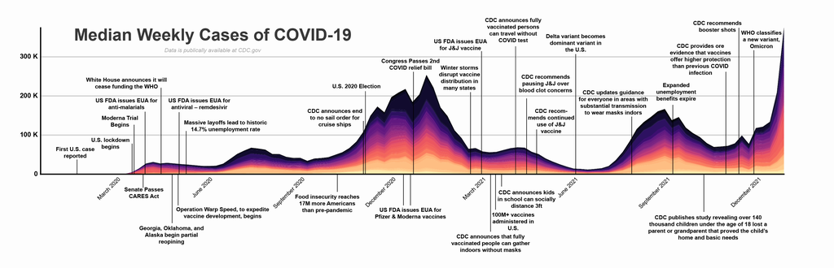

Final Annotated Graphic